# Lab 6 Time Series & Forecasting

Brad Anderson

February 22, 2018

```r
library(tidyverse)
library(forecast)
library(tseries)
energy <- read.csv("energy.csv")

class(energy)
```

```
## [1] "data.frame"
```

## 3. Convert to ‘ts’ data

The timeseries package only works with ‘ts’ class data. The base ‘plot’ package also understands ‘ts’ data also, among many others

Our data is measured monthly

```r
res_ts <- ts(energy$res_total, frequency = 12, start = c(1973, 1)) #Each year, starting in January 1973

#res_ts
```

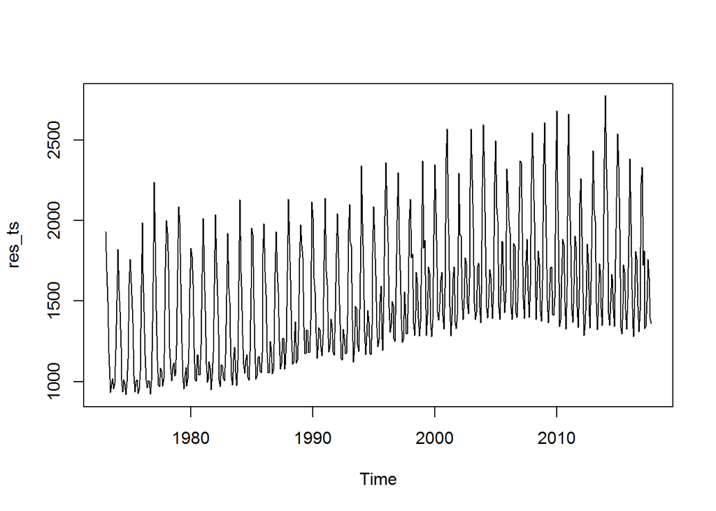

```r
plot(res_ts)
```

This data is a weird combo of additive and multiplicative data. Seasonality? YES Notable Outliers? NO

## 4. Decompose the ts data.

decompose() function

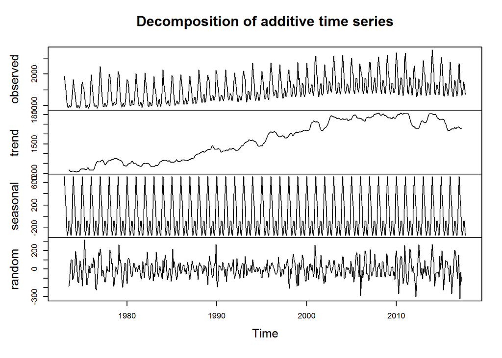

```r
res_dc <- decompose(res_ts)

plot(res_dc)
```

random = residiuals, looks like white noise, somewhat randomly distributed, the meanas are not changing

## 5. Other fast, cool ways to explore your ts data

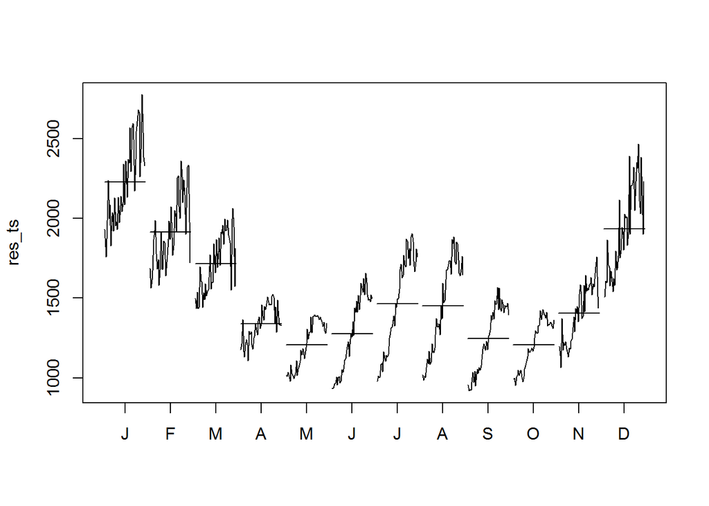

```r
monthplot(res_ts)
```

For each separate month, this shows me how that values has changed over ALL years included in this study.

Ex. April has not changed a lot, but summer months are showing a drastic increase in energy consumption.

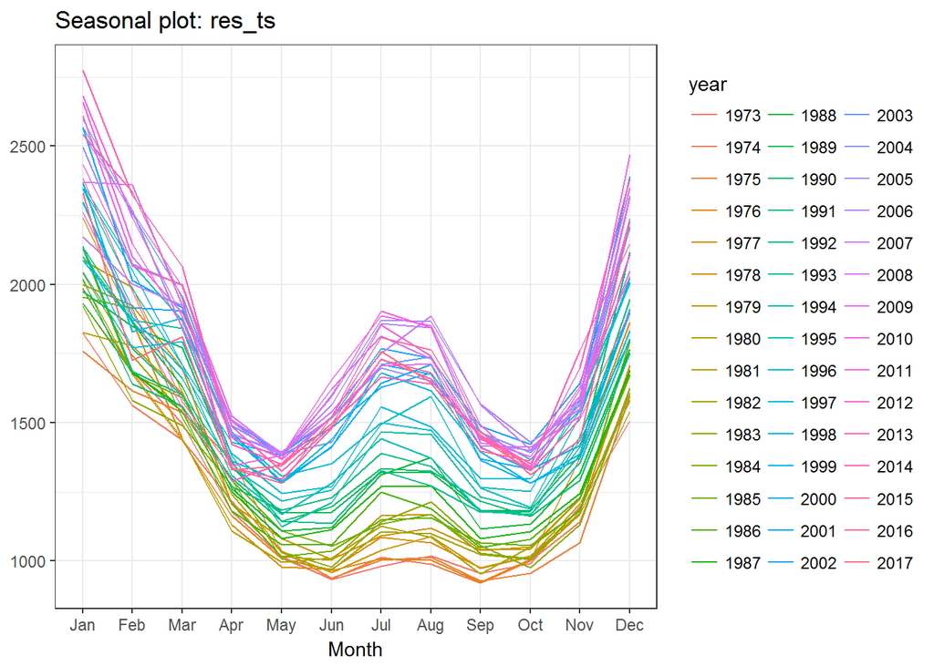

```r
ggseasonplot(res_ts) +
  theme_bw()
```

Taking data for each year and gives it a different color. Orange colors in the the 1970s are at the bottom, with increasing energy use over the years.

## Part 6. SImple moving average (smoothing)

Use the ‘ma’ function in the forecast package

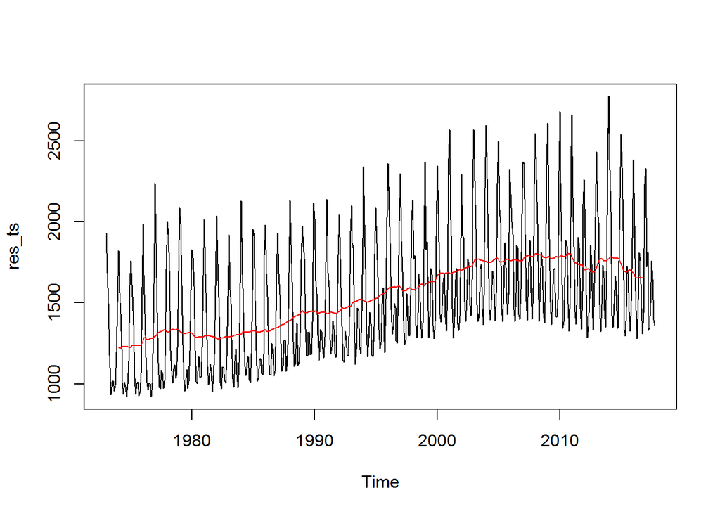

```r
sma_res <- ma(res_ts, order = 24) #changing the number will adjust the moving average
plot(res_ts)
lines(sma_res, col = "red")
```

## 7. exploring autocorrelation (ACF)

A good way to explore seasonality, especially if your data looks like random noise.

1. basic way using ACF() which plots the correlogram
2. gg way using ggtsdisplay()

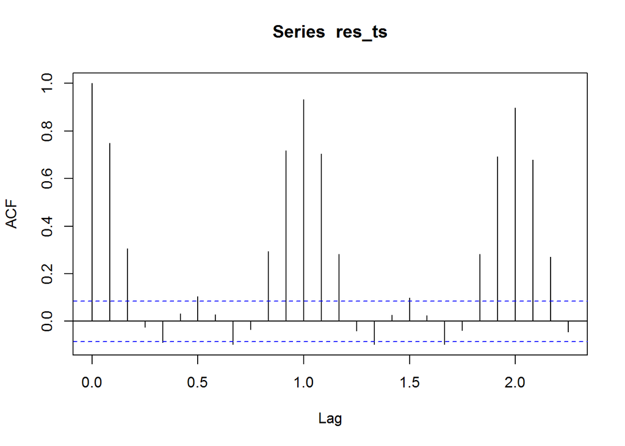

```r
acf(res_ts)
```

Clear oscillating pattern, which shows a very stable, repeated correlation. This is because this a VERY stable seasonal data overall.

1.0 = 1 year in this case

Values that are separated by ~12 months are highly correlated.

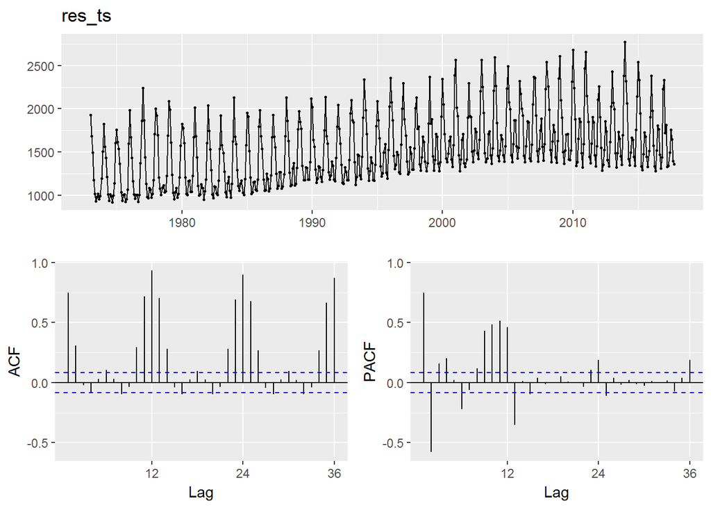

```r
ggtsdisplay(res_ts)
```

The original data on the top. The lag has months on the x axis.

## Augmented Dickey-Fuller Test for Stationarity

Null hypothesis: data are NOT stationary ALternative hypothesis: data are stationary

Ex. If p value is 0.03 (assuming sig level of alpha = 0.05), then I reject the null hypothesis, thus I retain the alternative hypothesis because think the data is stationary data.

```r
adf_res <- adf.test(res_ts)
adf_res
```

```
##
##  Augmented Dickey-Fuller Test
##
## data:  res_ts
## Dickey-Fuller = -11.342, Lag order = 8, p-value = 0.01
## alternative hypothesis: stationary
```

## 9. Holt-Winters Exponential SMoothing

Also called triple exponential smoothing, which considers three different weighted components from previous values.

Making predicitons of recent values that are weighted more strongly than observations in the past.

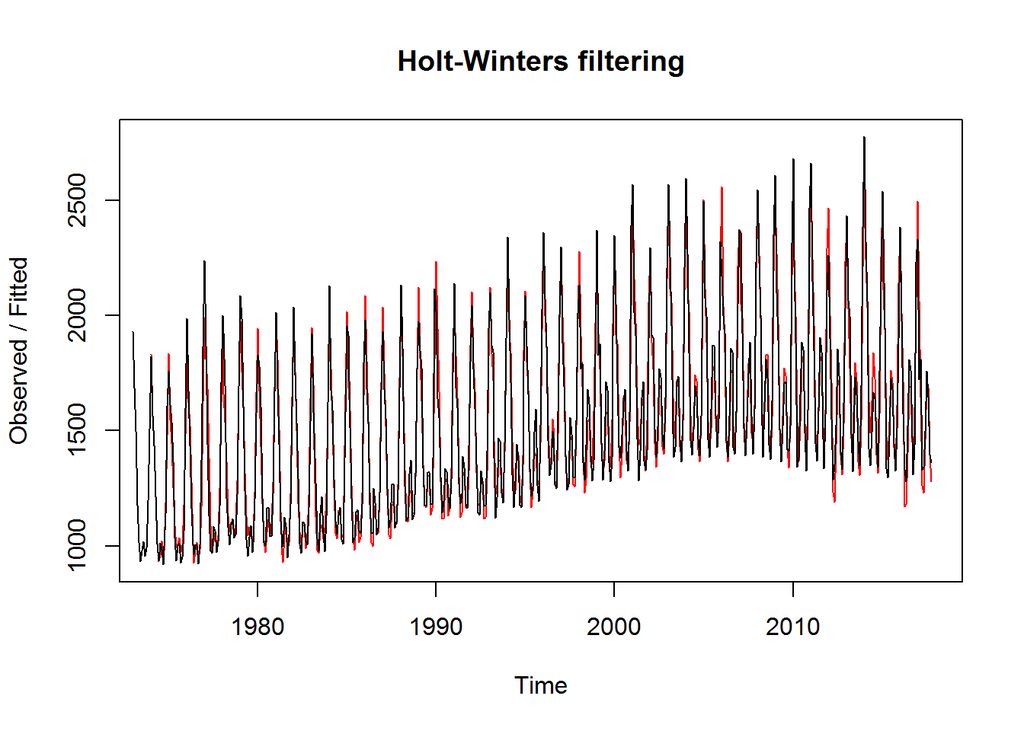

```r
res_hw <- HoltWinters(res_ts) #This does not make a forecast on its own...
plot(res_hw)
```

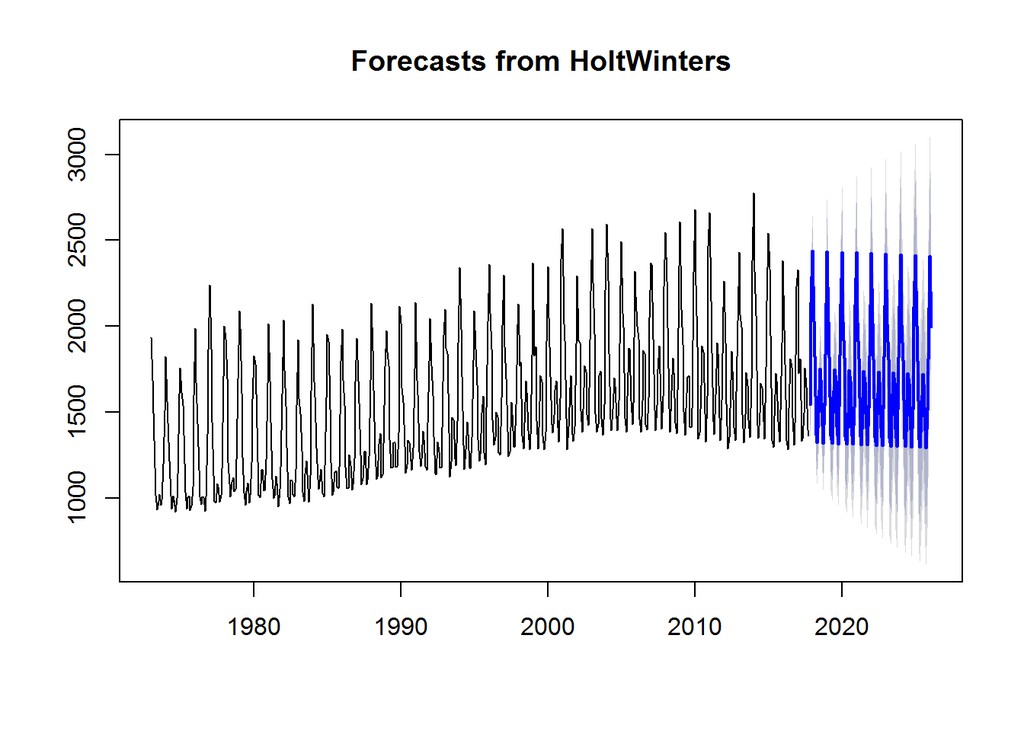

```r
res_forecast <- forecast(res_hw, h = 100) #whatever you put into it, it recognizes the model type
plot(res_forecast)
```

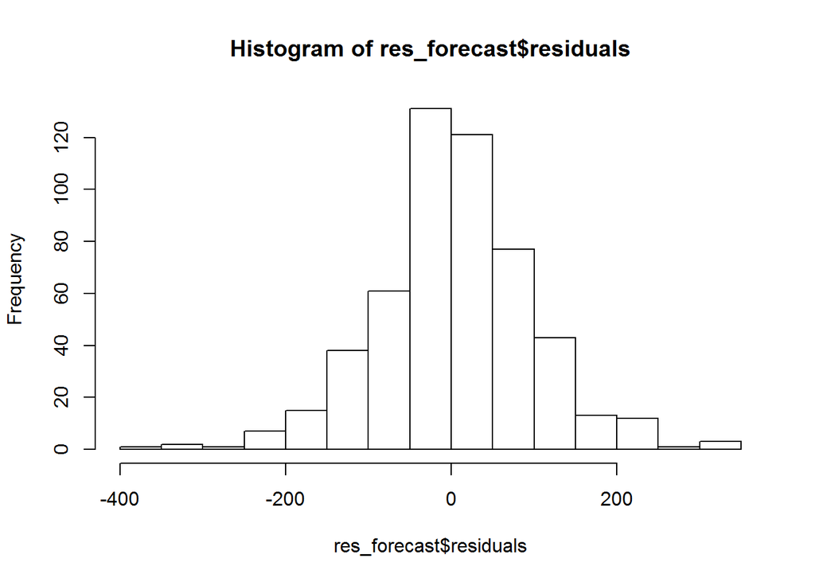

```r
hist(res_forecast$residuals)
```

Relatively small error bars because this data are SO repeated, not a lot of noise. I can be decently confidence using this to make predictions.

Residuals look normally distributed. Happy! Does not look like it is biased to higher or lower values.

It will not pull trends out of noisey data.

## 10. ARIMA using auto.arima() function

Finds p,d,q values for seasonal and non-seasonal components of time series, but if you were truly presenting these values you would want a more rigorous method.

It’s dangerously easy…

```r
res_pdq <- auto.arima(res_ts)
res_pdq
```

```
## Series: res_ts
## ARIMA(1,0,2)(0,1,1)[12] with drift
##
## Coefficients:
##         ar1      ma1      ma2     sma1   drift
##       0.990  -0.4821  -0.4196  -0.8128  0.7520
## s.e.  0.011   0.0407   0.0397   0.0253  0.5872
##
## sigma^2 estimated as 7326:  log likelihood=-3090.52
## AIC=6193.05   AICc=6193.21   BIC=6218.64
```

AIC models are displayed, so you can see the best-fit model.

Nonseasonal/sesonal PDQ values: (1,0,2)(0,1,1)

```r
res_arima <- arima(res_ts, order = c(1,0,2), seasonal = list(order = c(0,1,1)))
```

Evaluate the residuals

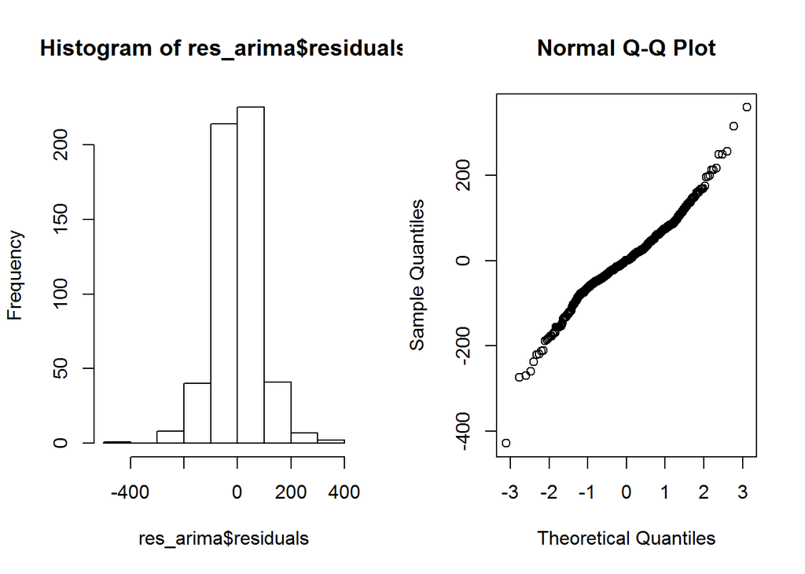

```r
par(mfrow = c(1,2))
hist(res_arima$residuals)
qqnorm(res_arima$residuals) #uses z distribution
```

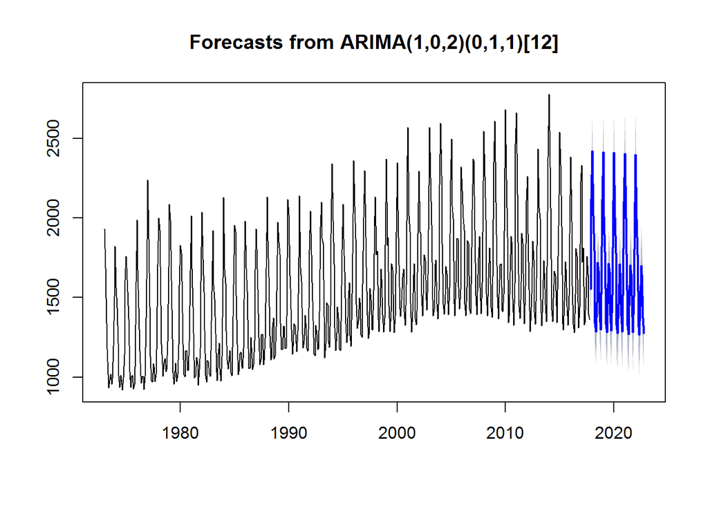

```r
forecast_res <- forecast(res_arima, h = 60)
plot(forecast_res)
```

if I want to convert the infomoration to a dataframe, for using in ggplot

```r
res_df <- data.frame(forecast_res)
```

This shows the confidence interbal data as well!